# movieRatings

A.S.

November 1, 2018

For Project 2, I will be using The Movies Dataset from Kaggle: https://www.kaggle.com/rounakbanik/the-movies-dataset/home

The dataset contains information from TMDB and GroupLens. I will be focusing on movie ratings.

## Load packages and data

This project will mainly use two packages, `dplyr` and `ggplot2`, to clean and visualize the dataset.

```r
library(dplyr)
```

```r
library(ggplot2)
library(ggrepel)
```

I had to throw in `ggrepel` too, let’s check that out later.

```r
movies <- read.csv('movies_metadata.csv', header = TRUE)
ratings <- read.csv('ratings_small.csv', header = TRUE)
movies <- select(movies, id, title, vote_average, vote_count, release_date, revenue, runtime, popularity, genres, budget)
abbr <- tbl_df(movies)
ratings <- tbl_df(ratings)
head(abbr)
```

```
## # A tibble: 6 × 10
##       id                       title vote_average vote_count release_date
##   <fctr>                      <fctr>        <dbl>      <int>       <fctr>
## 1    862                   Toy Story          7.7       5415   1995-10-30
## 2   8844                     Jumanji          6.9       2413   1995-12-15
## 3  15602            Grumpier Old Men          6.5         92   1995-12-22
## 4  31357           Waiting to Exhale          6.1         34   1995-12-22
## 5  11862 Father of the Bride Part II          5.7        173   1995-02-10
## 6    949                        Heat          7.7       1886   1995-12-15
## # ... with 5 more variables: revenue <dbl>, runtime <dbl>,
## #   popularity <fctr>, genres <fctr>, budget <fctr>
```

```r
head(ratings)
```

```
## # A tibble: 6 × 4
##   userId movieId rating  timestamp
##    <int>   <int>  <dbl>      <int>
## 1      1      31    2.5 1260759144
## 2      1    1029    3.0 1260759179
## 3      1    1061    3.0 1260759182
## 4      1    1129    2.0 1260759185
## 5      1    1172    4.0 1260759205
## 6      1    1263    2.0 1260759151
```

```r
dim(abbr)
```

```
## [1] 45466    10
```

```r
dim(ratings)
```

```
## [1] 100004      4
```

## Finding out about data

We’re mainly interested in the `ratings` table, but we will use the `movies` table in order to make more conclusions about ratings by budget, date, runtime, and more.

```r
ratings
```

```
## # A tibble: 100,004 × 4
##    userId movieId rating  timestamp
##     <int>   <int>  <dbl>      <int>
## 1       1      31    2.5 1260759144
## 2       1    1029    3.0 1260759179
## 3       1    1061    3.0 1260759182
## 4       1    1129    2.0 1260759185
## 5       1    1172    4.0 1260759205
## 6       1    1263    2.0 1260759151
## 7       1    1287    2.0 1260759187
## 8       1    1293    2.0 1260759148
## 9       1    1339    3.5 1260759125
## 10      1    1343    2.0 1260759131
## # ... with 99,994 more rows
```

```r
unique(ratings$rating) #what are the different values in this col?
```

```
##  [1] 2.5 3.0 2.0 4.0 3.5 1.0 5.0 4.5 1.5 0.5
```

```r
length(unique(ratings$userId)) #how many users are represented in this subset?
```

```
## [1] 671
```

```r
abbr
```

```
## # A tibble: 45,466 × 10
##        id                       title vote_average vote_count release_date
##    <fctr>                      <fctr>        <dbl>      <int>       <fctr>
## 1     862                   Toy Story          7.7       5415   1995-10-30
## 2    8844                     Jumanji          6.9       2413   1995-12-15
## 3   15602            Grumpier Old Men          6.5         92   1995-12-22
## 4   31357           Waiting to Exhale          6.1         34   1995-12-22
## 5   11862 Father of the Bride Part II          5.7        173   1995-02-10
## 6     949                        Heat          7.7       1886   1995-12-15
## 7   11860                     Sabrina          6.2        141   1995-12-15
## 8   45325                Tom and Huck          5.4         45   1995-12-22
## 9    9091                Sudden Death          5.5        174   1995-12-22
## 10    710                   GoldenEye          6.6       1194   1995-11-16
## # ... with 45,456 more rows, and 5 more variables: revenue <dbl>,
## #   runtime <dbl>, popularity <fctr>, genres <fctr>, budget <fctr>
```

```r
ref <- transform(abbr, id = as.integer(id), popularity = as.numeric(popularity), budget = as.numeric(budget), release_date = as.Date(release_date))
ref<- arrange(ref, id)

apply(ratings, 2, function(x) any(is.na(x))) #find out if there are any nas
```

```
##    userId   movieId    rating timestamp
##     FALSE     FALSE     FALSE     FALSE
```

```r
apply(ref, 2, function(x) any(is.na(x)))
```

```
##           id        title vote_average   vote_count release_date
##        FALSE        FALSE         TRUE         TRUE         TRUE
##      revenue      runtime   popularity       genres       budget
##         TRUE         TRUE        FALSE        FALSE        FALSE
```

```r
sum(is.na(ref$vote_count)) #so then how many nas are there
```

```
## [1] 6
```

```r
sum(is.na(ref$runtime))
```

```
## [1] 263
```

```r
length(unique(ratings$movieId)) #seems like this table is organized by users voting on movies, there might be movies voted on multiple times
```

```
## [1] 9066
```

```r
length(unique(ratings$movieId))/nrow(ratings)
```

```
## [1] 0.09065637
```

## Modifying Data

### Averaging rating

I’m not quite sure how the `popularity` column in the reference table has been calculated, but I want to work with average ratings for movies, not individual ratings. So I will use summarize to create a new kind of rating table.

```r
avged <- ratings %>%
  group_by(movieId) %>%
  summarize(avg_rating = mean(rating), rating_count = n()) %>%
  print
```

```
## # A tibble: 9,066 × 3
##    movieId avg_rating rating_count
##      <int>      <dbl>        <int>
## 1        1   3.872470          247
## 2        2   3.401869          107
## 3        3   3.161017           59
## 4        4   2.384615           13
## 5        5   3.267857           56
## 6        6   3.884615          104
## 7        7   3.283019           53
## 8        8   3.800000            5
## 9        9   3.150000           20
## 10      10   3.450820          122
## # ... with 9,056 more rows
```

Perfect. Now we can do a preliminary graph, even though we don’t know very much about what kinds of movies there are or even which movies are which.

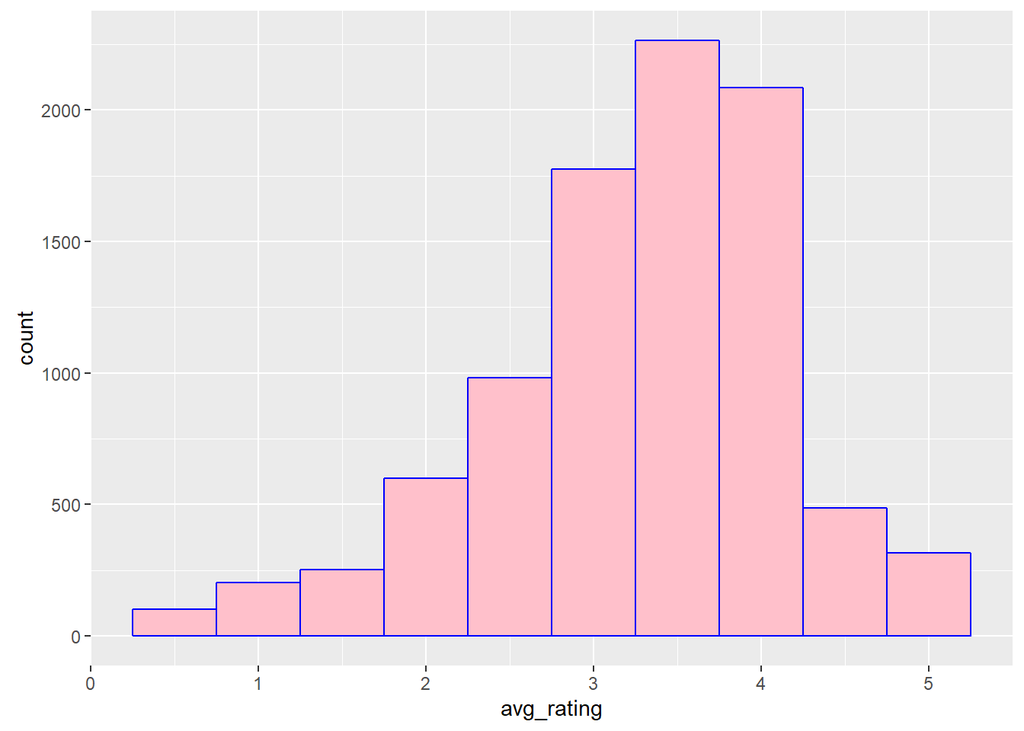

```r
x <- ggplot(avged, aes(x = avg_rating)) +
  geom_histogram(binwidth = 0.5, color = "blue", fill = "pink")
x
```

This is divided into bins of 0.5 rating, since we kind of made the ratings into a continuous variable by averaging it.

### Merging Movie Metadata and Average Ratings

I want to be able to compare movies based on other attributes, though, so let’s put the two dataframes together. Looks pretty cool with all the `movieId`s lined up.

```r
final <- merge(avged, ref, by.x = "movieId", by.y = "id", all.x = TRUE)
head(final, 10)
```

```
##    movieId avg_rating rating_count                               title
## 1        1   3.872470          247 Lock, Stock and Two Smoking Barrels
## 2        2   3.401869          107           La estrategia del caracol
## 3        3   3.161017           59                      Young Einstein
## 4        4   2.384615           13                      Flight Command
## 5        5   3.267857           56                             Hounded
## 6        6   3.884615          104                           Mona Lisa
## 7        7   3.283019           53                           Bloodwork
## 8        8   3.800000            5                           The Saint
## 9        9   3.150000           20    The Great Los Angeles Earthquake
## 10      10   3.450820          122                       Mr. Thank You
##    vote_average vote_count release_date   revenue runtime popularity
## 1           7.5       1671   1998-03-05   3897569     105      36946
## 2           7.2          9   1993-12-25         0     116       7809
## 3           4.5         46   1988-12-15         0      91      32374
```

[output cut: 29 more lines]

```r
final <- filter(final, rating_count > 7)
head(final, 10)
```

```
##    movieId avg_rating rating_count                               title
## 1        1   3.872470          247 Lock, Stock and Two Smoking Barrels
## 2        2   3.401869          107           La estrategia del caracol
## 3        3   3.161017           59                      Young Einstein
## 4        4   2.384615           13                      Flight Command
## 5        5   3.267857           56                             Hounded
## 6        6   3.884615          104                           Mona Lisa
## 7        7   3.283019           53                           Bloodwork
## 8        9   3.150000           20    The Great Los Angeles Earthquake
## 9       10   3.450820          122                       Mr. Thank You
## 10      11   3.689024           82                         Desperation
##    vote_average vote_count release_date revenue runtime popularity
## 1           7.5       1671   1998-03-05 3897569     105      36946
## 2           7.2          9   1993-12-25       0     116       7809
## 3           4.5         46   1988-12-15       0      91      32374
```

[output cut: 29 more lines]

## Random 100 Movies Intermission Break

We take an intermission here to let you randomly select 100 movies to see where they rank, so you can read their `title`s. I organized their ranking in color so it’s easier to parse, and also look at that fancy `ggrepel`. Sweet. Each time you run this chunk, the 100 movies will be different. It’s probably going to be sorrily permanent in knit, though.

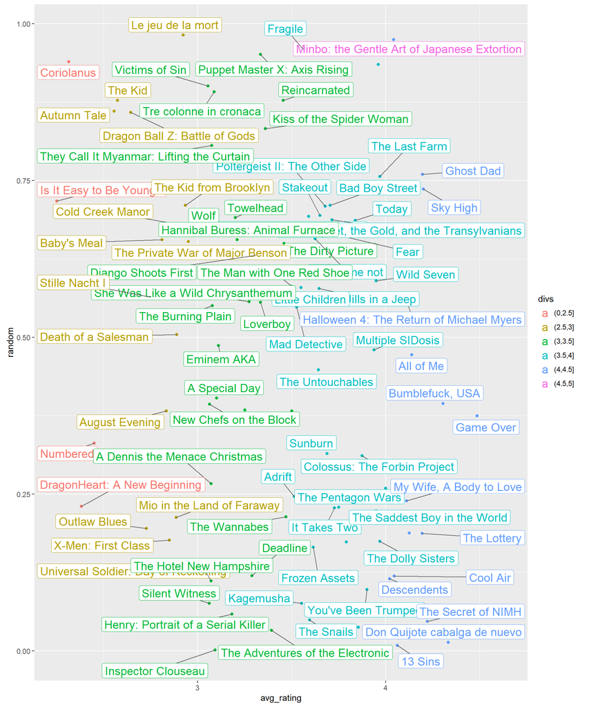

```r
new <- final
len <- nrow(final)
new$random <- runif(len)
new$divs <- cut(new$avg_rating, breaks = c(0, 2.5, 3.0, 3.5, 4.0, 4.5, 5))
n <- ggplot(new[sample.int(len, 100),], aes(x = avg_rating, y = random, label = title, color = divs)) +
  geom_point() +
  geom_label_repel(size = 5)
n
```

## Searching For A Trend, Some Correlation

Let’s compare `popularity` and average `rating` and see if that had anything to do with each other.

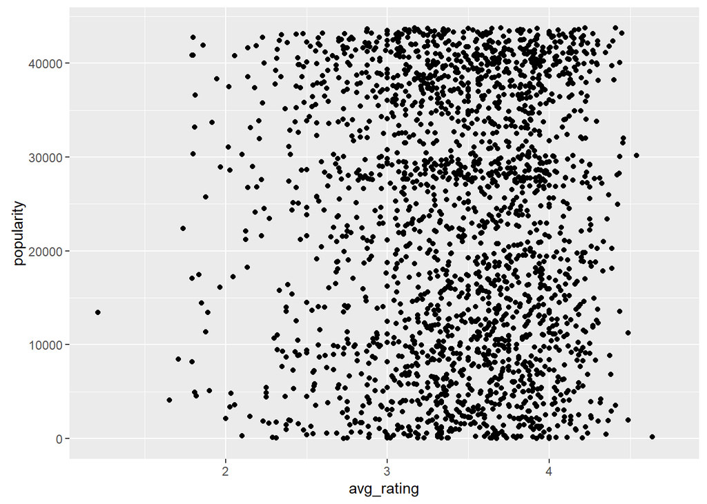

```r
y <- ggplot(final, aes(x = avg_rating, y = popularity)) +
  geom_jitter()
y
```

Okay, so it doesn’t look like there’s much of a correlation between `popularity` and `rating`. Also, for some reason, there are a few (350) rows with NAs, so those were omitted from the graph.

I’m not quite sure what `vote_average` means, so let’s check that out against `avg_rating`.

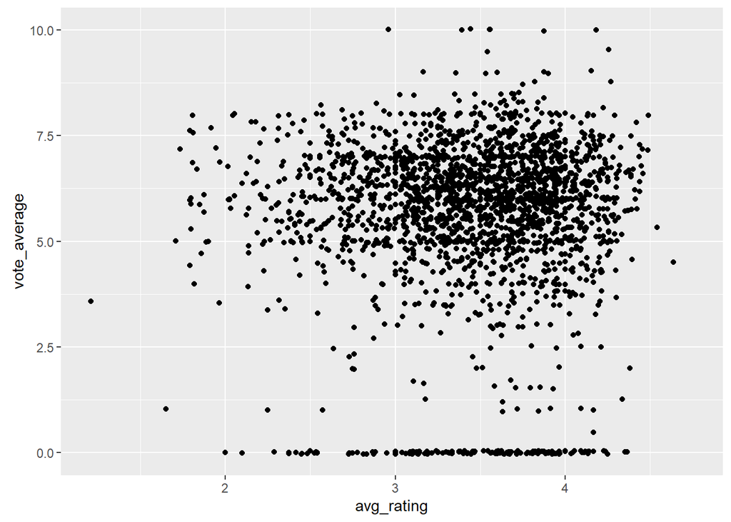

```r
z <- ggplot(final, aes(x = avg_rating, y = vote_average)) +
  geom_jitter()
z
```

Okay, this looks a little more promising. There seems to be a clump towards the middle, with about 3.5 rating and an average of around 6.25. There are apparently a lot of movies with a `vote_average` of 0, presumably because someone didn’t enter any data for that movie, which makes a line on the bottom. They probably should have said `NA` instead.

Still, there is no clear trend, just a centralization of the data. Let’s keep going and see if we can find any interesting trends. Let’s try `revenue`.

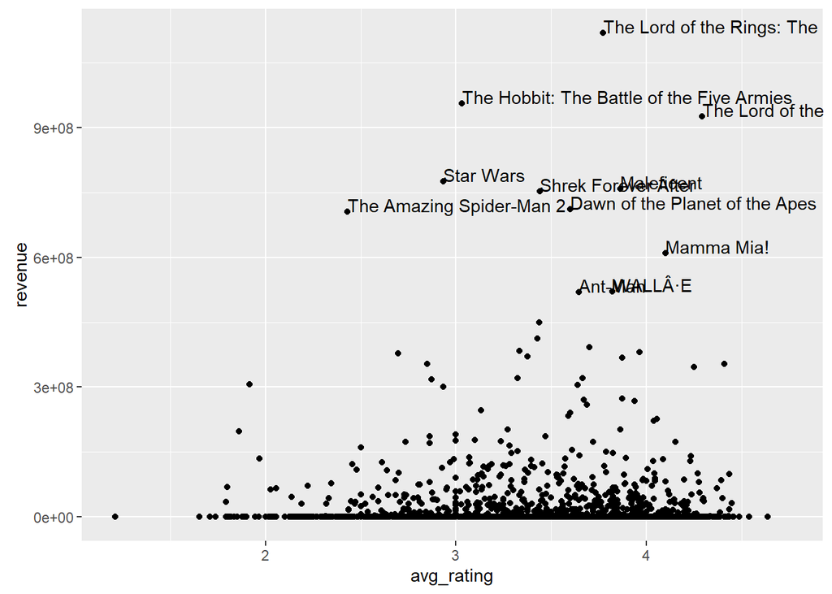

```r
a <- ggplot(final, aes(x = avg_rating, y = revenue)) +
  geom_jitter() +
  geom_text(aes(label=ifelse(revenue > 450000000, as.character(title), '')),hjust = 0,vjust = 0)
a
```

So maybe not. But surely `popularity` was somehow calculated based on `revenue`?

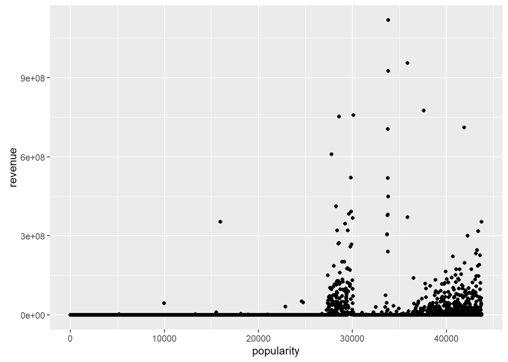

```r
b <- ggplot(final, aes(x = popularity, y = revenue)) +
  geom_jitter()
b
```

You know, if not, then okay, man. Another problem was that a *lot* of the revenue columns are set to 0 (which I think probably should have been `NA`s). I wonder if we can find any interesting correlations at all.

## Filtering By Recent Movies

How about release date? What about just knowing about movies from the 2010s?

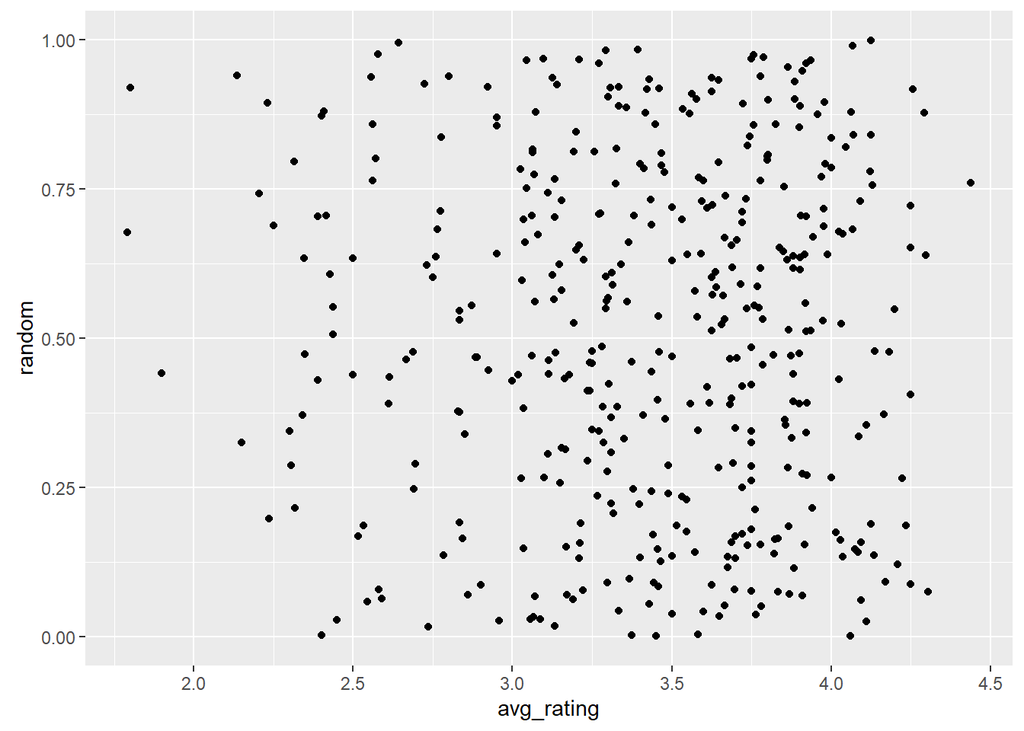

```r
recent <- filter(final, release_date > "2010-01-01")
recent$random <- runif(419)

c <- ggplot(recent, aes(x = avg_rating, y = random)) +
  geom_point()
c
```

Still not very meaningful, but at least we’ve got less dots. Not sure what attributes we have access to that would help us figure out what makes the best rated movies the best. I guess we can still find out which ones are the best.

```r
top_recent <- filter(recent, avg_rating > 4.0)
arrange(top_recent, avg_rating)
```

```
##    movieId avg_rating rating_count
## 1     1234   4.015873           63
## 2     2303   4.023810           21
## 3     2324   4.025253           99
## 4      671   4.030303           33
## 5     1960   4.032258           31
## 6      599   4.035714           14
## 7     4011   4.036842           95
## 8     3629   4.045455           11
## 9     5952   4.061170          188
## 10    8154   4.062500            8
## 11    5782   4.068182           22
## 12    6350   4.068182           22
## 13    4103   4.071429           14
## 14    3201   4.075000           20
```

[output cut: 210 more lines]

```r
top_recent
```

```
##    movieId avg_rating rating_count
## 1      194   4.291667           24
## 2      296   4.256173          324
## 3      306   4.171875           32
## 4      475   4.209677           31
## 5      581   4.235294           17
## 6      593   4.138158          304
## 7      599   4.035714           14
## 8      671   4.030303           33
## 9     1136   4.224138          145
## 10    1175   4.166667           30
## 11    1212   4.250000           38
## 12    1230   4.093750           80
## 13    1234   4.015873           63
## 14    1259   4.093750          112
```

[output cut: 210 more lines]

I’m pretty sure we’re missing some important movies here, like Frozen and Star Wars 7, and I think that’s because we’re not using the full ratings .csv file. But I don’t want to overwork RStudio, so we’re going to deal with it. Hope this has been interesting.

For future further exploration, I would figure out how to parse movies by genre and graph info based on that. I’m not sure how to find more meaningful conclusions, though. I think I definitely need better questions, and ways to narrow data into smaller, more interesting subsets.